# Re-selling MC Goods (190821)

Matthias Fuchs

8/21/2019

# Data description

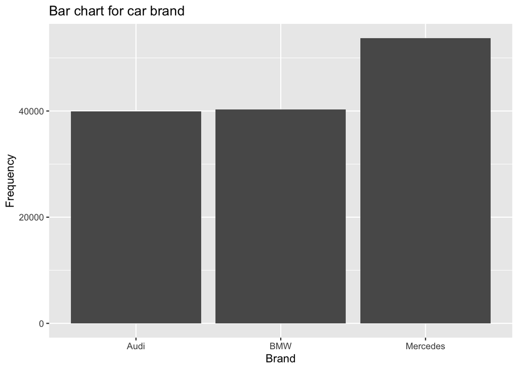

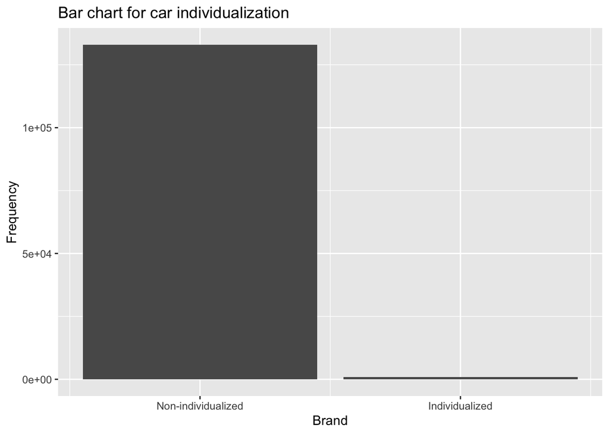

```
## [1] "961 out of 133940 cars are individualized."
```

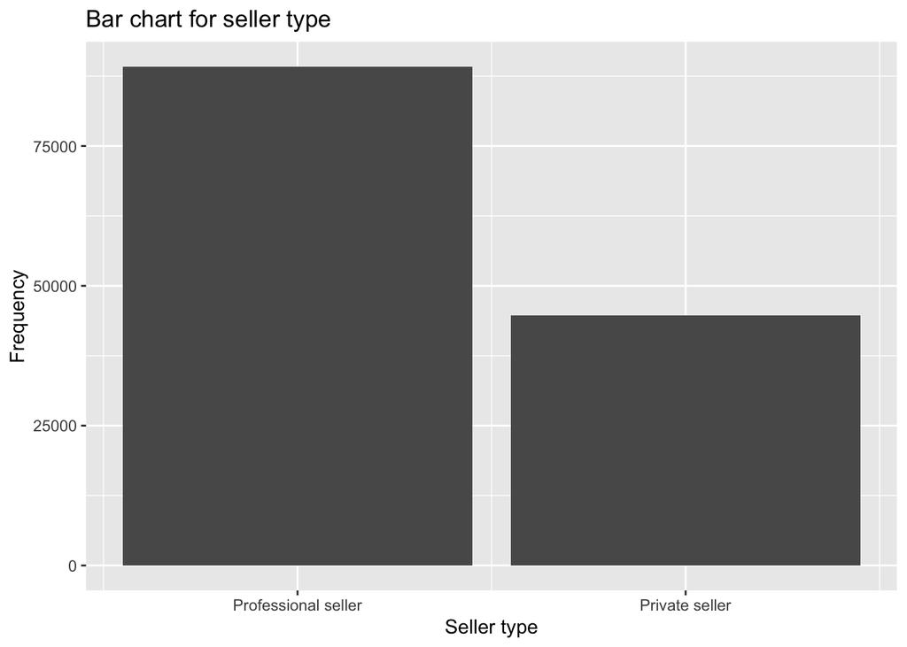

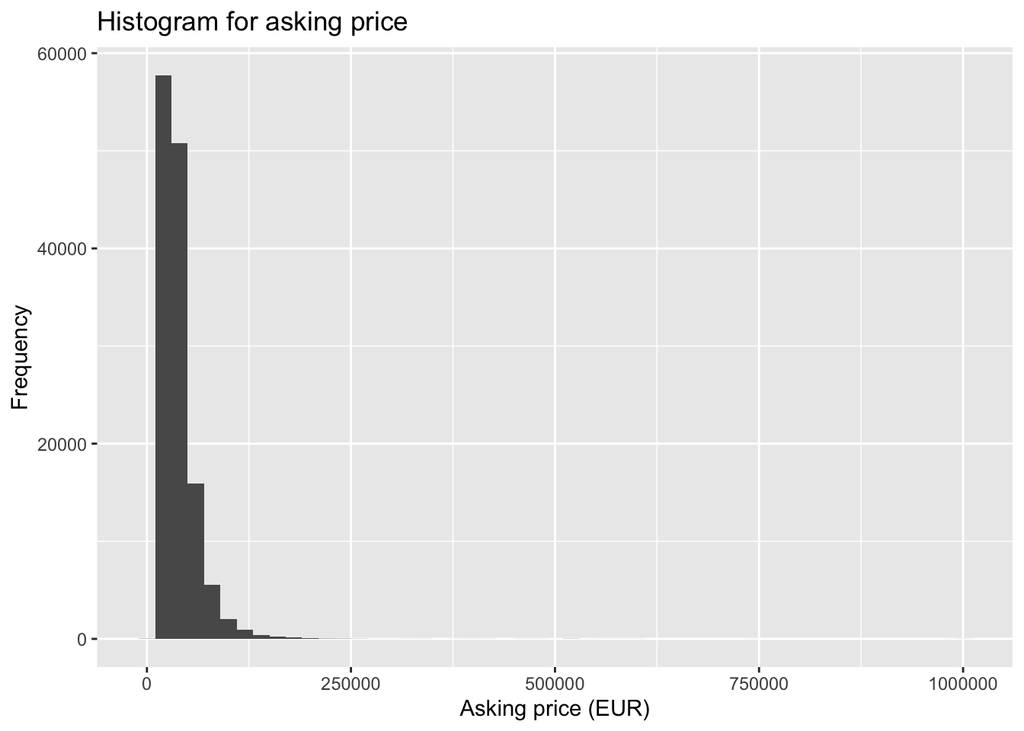

# Checking horizontal vs. vertical customizations

The following multilevel models are included in the below table. All are linear mixed effects models containing random effects of Car Type, Body Type, Color, Fuel Type, and Transmission Type on the intercept.

- Model1: Normal ML-regression including all variables.
- Model2: Model1 + Interaction of individual package and seller type.
- Model3: Model1 + Interaction of individual package and age in days.
- Model4: Like model 1, but the DV is the system-assigned price category (1-cheap to 7-expensive).
- Model5: Model4 + Interaction of individual package and seller type.

*Dependent variable:*

Price

pricerating

(1)

(2)

(3)

(4)

(5)

sport

1,583.089***

1,584.261***

1,587.811***

0.042***

0.042***

(93.871)

(93.856)

(93.727)

(0.009)

(0.009)

individual

-3,651.540***

-5,306.104***

20,444.580***

0.067

0.077

(425.854)

(494.536)

(1,286.992)

(0.046)

(0.047)

privateseller

631.954**

594.600**

605.720**

-0.145***

-0.144***

(202.320)

(202.367)

(202.015)

(0.016)

(0.016)

Power

107.532***

107.531***

107.163***

-0.001***

-0.001***

(1.570)

(1.570)

(1.568)

(0.0001)

(0.0001)

sqrt(Mileage)

-31.402***

-31.368***

-31.434***

0.001***

0.001***

(0.687)

(0.687)

(0.686)

(0.0001)

(0.0001)

sqrt(ageindays)

-636.360***

-636.426***

-629.095***

-0.007***

-0.007***

(6.792)

(6.790)

(6.791)

(0.001)

(0.001)

hud

1,165.528***

1,181.273***

1,144.627***

0.114***

0.114***

(136.646)

(136.644)

(136.440)

(0.016)

(0.016)

acc

164.933

164.156

185.908

0.003

0.002

(177.912)

(177.882)

(177.642)

(0.015)

(0.015)

glasdach

495.660*

493.905*

506.821**

0.031

0.031

(196.639)

(196.607)

(196.338)

(0.018)

(0.018)

laser

972.067

1,061.509*

907.575

-0.003

-0.003

(526.160)

(526.248)

(525.362)

(0.096)

(0.096)

led

-958.402***

-962.990***

-945.226***

-0.065***

-0.065***

(82.914)

(82.903)

(82.789)

(0.007)

(0.007)

leather

-110.820

-109.384

-119.617

0.035*

0.035*

(154.311)

(154.285)

(154.074)

(0.015)

(0.015)

navi

-1,437.174***

-1,434.558***

-1,456.591***

-0.065***

-0.065***

(78.882)

(78.870)

(78.767)

(0.007)

(0.007)

standheizung

446.431

426.131

451.171

-0.084**

-0.084**

(306.437)

(306.401)

(305.966)

(0.026)

(0.026)

individual:privateseller

6,352.746***

-0.249

(965.809)

(0.231)

individual:sqrt(ageindays)

-992.110***

(50.013)

Constant

52,409.030***

52,372.210***

52,369.340***

3.538***

3.538***

(4,061.080)

(4,052.240)

(4,095.315)

(0.073)

(0.073)

Observations

128,217

128,217

128,217

74,773

74,773

Log Likelihood

-1,392,586.000

-1,392,557.000

-1,392,385.000

-93,603.350

-93,603.310

Akaike Inf. Crit.

2,785,215.000

2,785,158.000

2,784,814.000

187,248.700

187,250.600

Bayesian Inf. Crit.

2,785,420.000

2,785,372.000

2,785,029.000

187,442.400

187,453.500

*Note:*

- p<0.05; ** p<0.01; *** p<0.001

```
## NOTE: sqrt(ageindays)individual is not a high-order term in the model
```

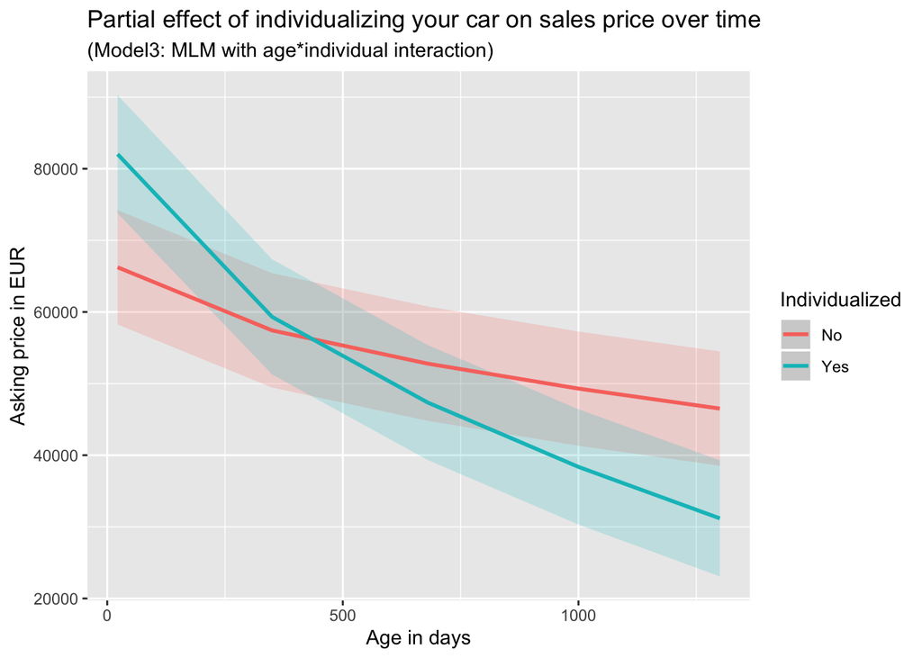

## Partial effects interaction plot - Seller type * individual package

```
## NOTE: privatesellerindividual is not a high-order term in the model
```

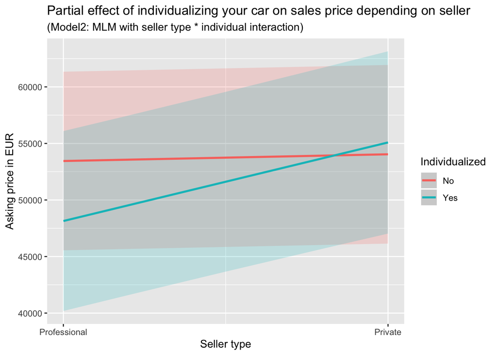

# Calculating relative popularity (inverted relative uniqueness)

$$Popularity_{i} = \prod_{feature = 1}^{n_{feature}} f(\frac{Count_{feature}}{n_{observations}})$$

$$Relative Popularity_{i} = (\frac{Popularity_{i}}{max(Popularity_{i},...,Popularity_{n})})*100$$

Where:

- Features are the aspects of the observations described below.
- $Count_{feature}$ is the count of all observations that are equal to this feature for $Observation_{i}$

Uniqueness is calculated in 3 different ways:

- Popularity1: Multiplied frequency ratio of Car Model, Fuel Type, Color, Body Type, and Transmission Type
- Popularity2: Features all car features of Popularity1, but adds the features Power (in HP),HUD, Laser,Sport, “Glasdach”, ACC, “Standheizung”,LED-Light, Leather Interior, Individual-Package, and Navigation System.
- Popularity3: Features all car features of Popularity1, but adds the feature Power (in HP).

This was done in order to try to calculate “uniqueness” rather than “feature-richness”. While Popularity1 errs on the side of “popularity vs. uniqueness” of the configuration, Popularity2 errs on the side of “feature-rich vs. bare-boned” configuration and Uniqueness3 tries to take a middle-ground.

Again, all are all are linear mixed effects models containing random effects of Car Type, Body Type, Color, Fuel Type, and Transmission Type on the intercept. The regression including Popularity3 was unsuccessful.

In order to avoid multicollinearity, several other features have been removed.

```
## fixed-effect model matrix is rank deficient so dropping 1 column / coefficient
```

*Dependent variable:*

Price

(1)

(2)

(3)

privateseller

1,154.302***

1,207.431***

1,151.377***

(198.688)

(199.020)

(198.687)

Power

106.008***

105.746***

106.272***

(1.524)

(1.523)

(1.519)

sqrt(Mileage)

-27.919***

-27.782***

-27.871***

(0.675)

(0.675)

(0.675)

sqrt(ageindays)

-662.241***

-664.745***

-663.355***

(6.748)

(6.737)

(6.732)

popularity1

8.853*

(3.794)

popularity2

-29.379***

(6.179)

Constant

49,195.700***

49,143.480***

49,059.630***

(3,708.230)

(3,703.776)

(3,704.261)

Observations

128,388

128,388

128,388

Log Likelihood

-1,395,552.000

-1,395,543.000

-1,395,557.000

Akaike Inf. Crit.

2,791,125.000

2,791,107.000

2,791,133.000

Bayesian Inf. Crit.

2,791,223.000

2,791,204.000

2,791,221.000

*Note:*

- p<0.05; ** p<0.01; *** p<0.001

# Holding duration

Again, all are all are linear mixed effects models containing random effects of Car Type, Body Type, Color, Fuel Type, and Transmission Type on the intercept.

*Dependent variable:*

ageindays

(1)

(2)

sport

-9.239***

-8.614***

(1.750)

(1.750)

individual

19.525*

23.358*

(7.941)

(9.231)

privateseller

181.627***

182.573***

(3.691)

(3.695)

Power

-0.162***

-0.149***

(0.028)

(0.028)

sqrt(Mileage)

3.358***

3.350***

(0.009)

(0.009)

hud

2.412

2.344

(2.547)

(2.549)

acc

-13.822***

-13.694***

(3.320)

(3.322)

glasdach

9.955**

8.751*

(3.668)

(3.669)

laser

-42.329***

-42.183***

(9.796)

(9.808)

led

-31.305***

-31.737***

(1.545)

(1.545)

leather

29.414***

31.094***

(2.878)

(2.878)

navi

34.180***

34.704***

(1.466)

(1.466)

standheizung

28.664***

28.553***

(5.716)

(5.721)

individual:privateseller

-13.169

(18.032)

Constant

86.673

82.834

(92.161)

(91.274)

Observations

128,225

128,225

Log Likelihood

-881,916.400

-882,020.300

Akaike Inf. Crit.

1,763,873.000

1,764,081.000

Bayesian Inf. Crit.

1,764,068.000

1,764,276.000

*Note:*

- p<0.05; ** p<0.01; *** p<0.001